# Project Business Statistics: E-news Express

### Bivariate Analysis

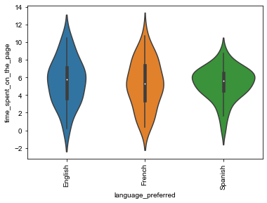

```python
ax = sns.violinplot(x="language_preferred", y="time_spent_on_the_page", data=df)
ax.set_xticklabels(ax.get_xticklabels(),rotation = 90)
sns.set(rc = {'figure.figsize':(20,10)})
plt.show()
```

Graph to illustrate how long time was spent on the page per language preferred. The means appear to be approximately equal, which is tested later.

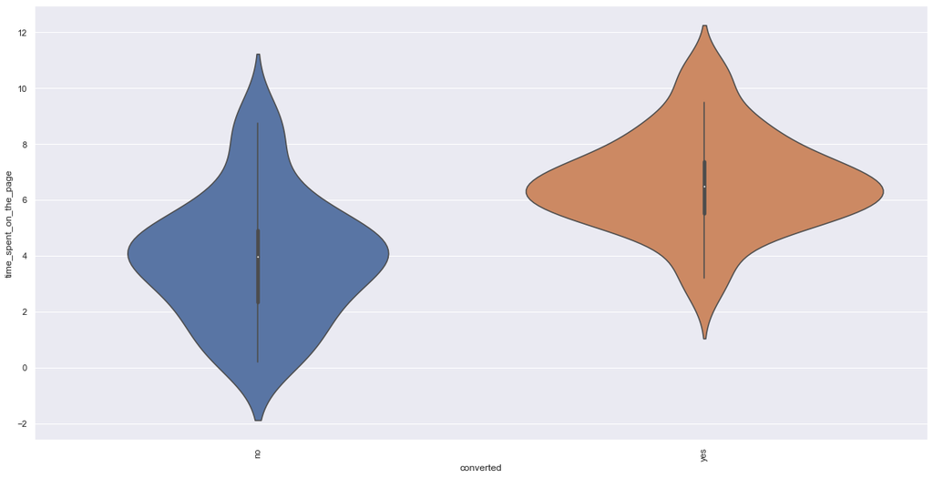

```python
ax = sns.violinplot(x="converted", y="time_spent_on_the_page", data=df)
ax.set_xticklabels(ax.get_xticklabels(),rotation = 90)
sns.set(rc = {'figure.figsize':(20,10)})
plt.show()
```

Time spent on the page versus the converted yes or no categories. The mean time spent on page for those who subscribed (yes) is higher than those who did not subscribe (no). Later in this project, the statistical validity of this visual observation is tested.

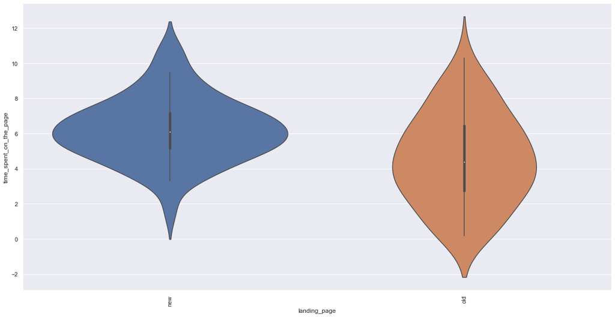

```python
ax = sns.violinplot(x="landing_page", y="time_spent_on_the_page", data=df)
ax.set_xticklabels(ax.get_xticklabels(),rotation = 90)
sns.set(rc = {'figure.figsize':(20,10)})
plt.show()
```

Time spent on page is plotted here versus the new and old landing pages. The new landing page has a higher mean time spent on page than the old landing page. The statistical validity of this difference is tested next in this project.

## 2. Do the users spend more time on the new landing page than the existing landing page? (10 Marks)

### Perform Visual Analysis

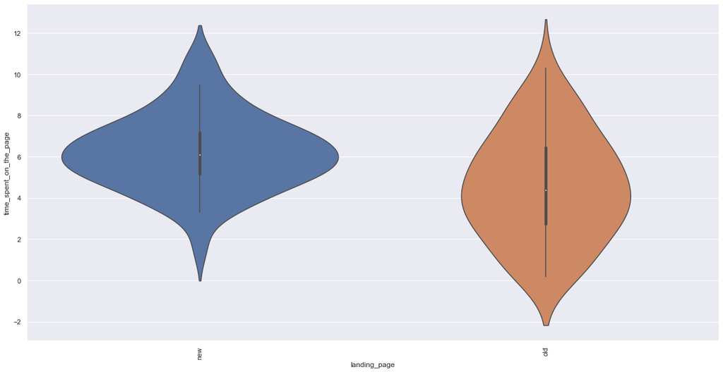

```python
ax = sns.violinplot(x="landing_page", y="time_spent_on_the_page", data=df)
ax.set_xticklabels(ax.get_xticklabels(),rotation = 90)
sns.set(rc = {'figure.figsize':(20,10)})
plt.show()
```

First pass visually, it appears that more time is spent on the new landing page. Further statistical analysis will confirm.

### Step 1: Define the null and alternate hypotheses

```python
H0: time spent on new landing page = time spent on old landing page
Ha: time spent on new landing page > time spent on old landing page
```

### Step 2: Select Appropriate test

2 sample independent T test

### Step 3: Decide the significance level

Standard alpha of .05 for a 95% confidence interval

### Step 4: Collect and prepare data

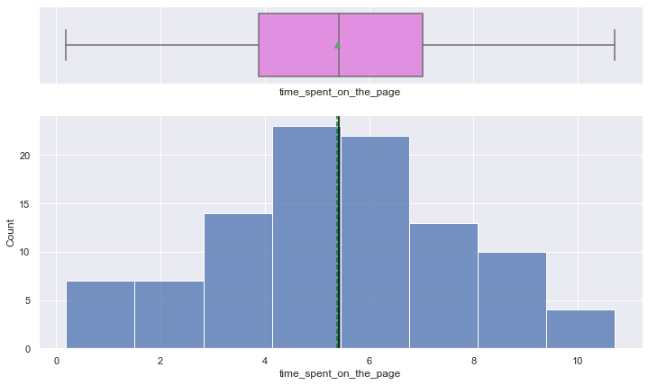

```python
histogram_boxplot(df, 'time_spent_on_the_page')
```

We can see that the dataset is approximately normally distributed. There are 100 tests total (greater than 30 required). We know that this was a random sampling of data with no given standard deviation. Therefore we have fulfilled all the requirements for a t-test.

```python
newdf = df.loc[(df['landing_page'] == 'new')]
newdf.head()
```

|  | user_id | group | landing_page | time_spent_on_the_page | converted | language_preferred |
| --- | --- | --- | --- | --- | --- | --- |
| 1 | 546468 | treatment | new | 7.13 | yes | English |
| 2 | 546462 | treatment | new | 4.40 | no | Spanish |
| 4 | 546459 | treatment | new | 4.75 | yes | Spanish |
| 6 | 546448 | treatment | new | 5.25 | yes | French |
| 8 | 546461 | treatment | new | 10.71 | yes | French |

```python
converteddf.shape
```

```
(54, 6)
```

```python
olddf = df.loc[(df['landing_page'] == 'old')]
olddf.head()
```

|  | user_id | group | landing_page | time_spent_on_the_page | converted | language_preferred |
| --- | --- | --- | --- | --- | --- | --- |
| 0 | 546592 | control | old | 3.48 | no | Spanish |
| 3 | 546567 | control | old | 3.02 | no | French |
| 5 | 546558 | control | old | 5.28 | yes | English |
| 7 | 546581 | control | old | 6.53 | yes | Spanish |
| 9 | 546548 | control | old | 2.08 | no | English |

By separating the single dataset into a new landing page dataset and an old landing page dataset, we can now do the statistical analysis. We see below that the means and standard deviations for the two datasets are different.

```python
newdf.describe()
```

|  | user_id | time_spent_on_the_page |
| --- | --- | --- |
| count | 50.00000 | 50.000000 |
| mean | 546467.50000 | 6.223200 |
| std | 14.57738 | 1.817031 |
| min | 546443.00000 | 1.650000 |
| 25% | 546455.25000 | 5.175000 |
| 50% | 546467.50000 | 6.105000 |
| 75% | 546479.75000 | 7.160000 |
| max | 546492.00000 | 10.710000 |

```python
olddf.describe()
```

|  | user_id | time_spent_on_the_page |
| --- | --- | --- |
| count | 50.00000 | 50.000000 |
| mean | 546566.50000 | 4.532400 |
| std | 17.67767 | 2.581975 |
| min | 546493.00000 | 0.190000 |
| 25% | 546555.25000 | 2.720000 |
| 50% | 546567.50000 | 4.380000 |
| 75% | 546579.75000 | 6.442500 |
| max | 546592.00000 | 10.300000 |

Continuous data - Yes, the time spent on page is measured on a continuous scale. Normally distributed populations - Yes, we are informed that the populations are assumed to be normal. Independent populations - As we are taking random samples for two different type of users, the two samples are from two independent populations. Unequal population standard deviations - As the sample standard deviations are different (1.8 vs 2.6), the population standard deviations may be assumed to be different. Random sampling from the population - Yes, we are informed that the collected sample is a simple random sample.

### Step 5: Calculate the p-value

```python
#import the required functions
from scipy.stats import ttest_ind

# find the p-value
test_stat, p_value = ttest_ind(newdf['time_spent_on_the_page'], olddf['time_spent_on_the_page'].dropna(), equal_var = False, alternative = 'greater')
print('The p-value is ', p_value)
```

```
The p-value is  0.0001392381225166549
```

### Step 6: Compare the p-value with $\alpha$

The p - value is 0.00014 which is less than our alpha of .05.

### Step 7: Draw inference

The p - value is 0.00014 which is less than our alpha of .05, so we must reject our null hypothesis that the means are equal. Therefore the average time spent on the new page is not equal to the average time spent on the old page. In fact the average time spent on the new page is higher than the old page.

**A similar approach can be followed to answer the other questions.**

## 3. Is the conversion rate (the proportion of users who visit the landing page and get converted) for the new page greater than the conversion rate for the old page? (10 Marks)

H0: Conversion rate for new landing page = conversion rate for old landing page Ha: Conversion rate for new landing page != conversion rate for old landing page

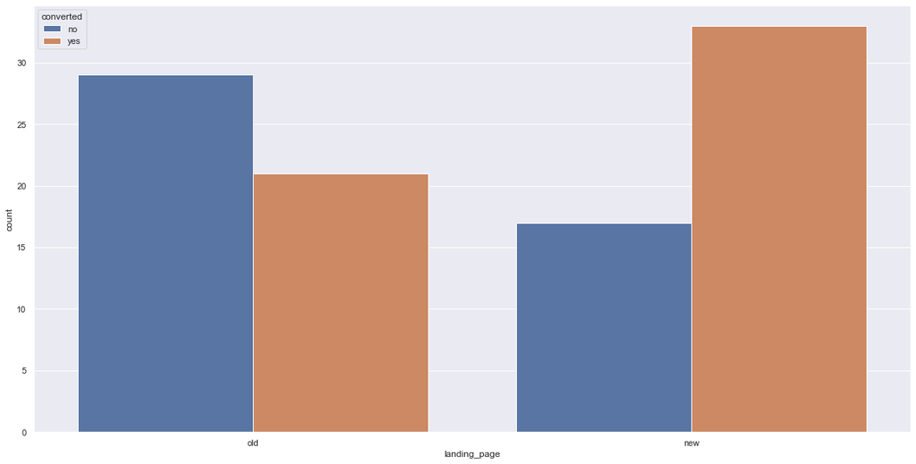

```python
sns.countplot(data=df, x='landing_page', hue = "converted")
```

Visually, the proportions of people who converted from the new landing page and the old landing page do not appear to be equal. Further statistical analysis will confirm.

Data requires a 2 proportion Z-test since the population standard deviation is not known. A standard alpha of 0.05 will be used.

Two proportion Z-Test Requirements: Binomally distributed population - Yes, a user either subscribes or does not subscribe. Random sampling from the population - Yes, we are informed that the collected sample is a simple random sample. Can the binomial distribution approximated to normal distribution - Yes. For binary data, CLT works slower than usual. The standard thing is to check whether np and n(1-p) are greater than or equal to 10. Here, n and p refer to the sample size and sample proportion respectively.

np >= 10 n(1-p) >= 10

Old Page Converts: Satisfies z-test requirements np = 50 *(21/50) = 21 >= 10 n(1-p) = 50* ((50-21)/50) = 29 >= 10

```python
new_page_convert_rate= len(newdf[(newdf['converted'] == 'yes')]) / len(newdf['converted'])
new_page_convert_rate

new_page_convert = len(newdf[newdf['converted'] == 'yes'])
new_page_convert
new_page_convert_total = len(newdf['converted'])
new_page_convert_total
print("New page converted is " + str(new_page_convert) + " out of " + str(new_page_convert_total))
```

```
New page converted is 33 out of 50
```

```python
old_page_convert_rate= len(olddf[(olddf['converted'] == 'yes')]) / len(olddf['converted'])
old_page_convert_rate

old_page_convert = len(olddf[(olddf['converted'] == 'yes')])
old_page_convert
old_page_convert_total = len(olddf['converted'])
old_page_convert_total
print("Old page converted is " + str(old_page_convert) + " out of " + str(old_page_convert_total))
```

```
Old page converted is 21 out of 50
```

```python
# import the required fuction
from statsmodels.stats.proportion import proportions_ztest

# set the counts of defective items
new_convert = np.array([33, 50])

# set the sample sizes
old_convert = np.array([21, 50])

# find the p-value
test_stat, p_value = proportions_ztest(old_convert, new_convert)
print('The p-value is ' + str(p_value))
```

```
The p-value is 4.02101846972016e-06
```

Since the p-value is much less than our alpha of 0.05 we reject the null hypothesis. Therefore we can conclude that the conversion rate for the new page is not equal to the conversion rate of the old page. The conversion rate is in fact higher for the new page.

## 4. Is the conversion and preferred language are independent or related? (10 Marks)

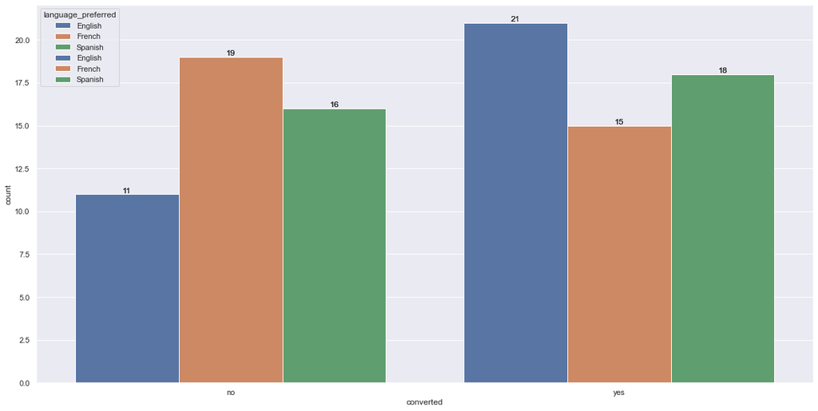

```python
sns.countplot(data = df, x = 'converted', hue = 'language_preferred')
ax = sns.countplot(x="converted", data=df, hue = 'language_preferred')

for p in ax.patches:
    label = p.get_height()  # count of each level of the category

    x = p.get_x() + p.get_width() / 2  # width of the plot
    y = p.get_height()  # height of the plot

    ax.annotate(label,(x, y),ha="center",va="center", size=12, xytext=(0, 5), textcoords="offset points")

plt.show()
```

Visually, language appears to be independent of conversion. Further statistical analysis will confirm.

Chi squared test for independence to be used to answer this question. Categorical variables - Yes Expected value of the number of sample observations in each level of the variable is at least 5 - Yes, the number of observations in each level is greater than 5. Random sampling from the population - Yes, we are informed that the collected sample is a simple random sample.

H0: language is independent of conversion Ha: language is not independent of conversion

```python
conversion_language = {'Conversion': ['yes','no'], 'English': [21, 11], 'French': [15, 19], 'Spanish': [18, 16]}
conversion_language_table = pd.DataFrame(data=conversion_language)
conversion_language_table.head()
```

|  | Conversion | English | French | Spanish |
| --- | --- | --- | --- | --- |
| 0 | yes | 21 | 15 | 18 |
| 1 | no | 11 | 19 | 16 |

```python
# import the required function
from scipy.stats import chi2_contingency

# find the p-value
chi, p_value, dof, expected = chi2_contingency(conversion_language_table.drop('Conversion', axis = 1))
print('The p-value is', p_value)
```

```
The p-value is 0.21298887487543447
```

The p-value is .21 which is greater than our alpha of 0.05, so we cannot reject our null hypothesis. Therefore language is independent of conversion.

## 5. Is the time spent on the new page same for the different language users? (10 Marks)

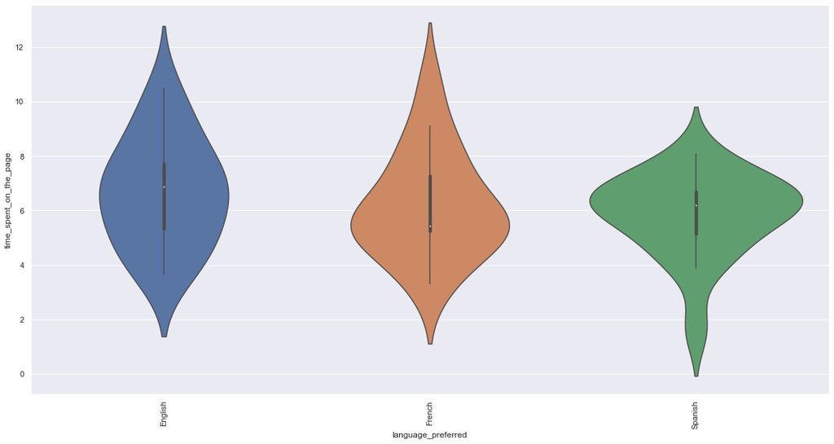

```python
ax = sns.violinplot(x="language_preferred", y="time_spent_on_the_page", data=newdf)
ax.set_xticklabels(ax.get_xticklabels(),rotation = 90)
sns.set(rc = {'figure.figsize':(20,10)})
plt.show()
```

Visual inspection shows the means to be approximately equal. Further statistical analysis will confirm.

```python
#ANOVA test
print(newdf.groupby("language_preferred")["time_spent_on_the_page"].mean())
```

```
language_preferred
English    6.663750
French     6.196471
Spanish    5.835294
Name: time_spent_on_the_page, dtype: float64
```

H0: all means are equal Ha: at least one mean is not equal

One-way ANOVA test is best to answer this question.

```
language_preferred
English    6.663750
French     6.196471
Spanish    5.835294
Name: time_spent_on_the_page, dtype: float64
```

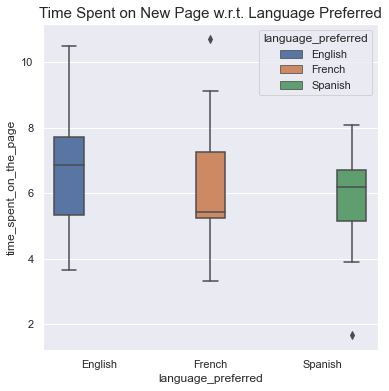

```python
print(newdf.groupby("language_preferred")["time_spent_on_the_page"].mean())

# draw the boxplot for visualization
fig, ax = plt.subplots(figsize = (6,6))
a = sns.boxplot(x= "language_preferred", y = 'time_spent_on_the_page' , data = newdf, hue = 'language_preferred')
a.set_title("Time Spent on New Page w.r.t. Language Preferred", fontsize=15)
plt.show()
```

```python
#check if time spent on page follows a normal distribution
# H0 time spent follows normal distribution
# Ha time spent does not follow normal distribution
from scipy import stats

# find the p-value
w, p_value = stats.shapiro(newdf['time_spent_on_the_page'])
print('The p-value is', p_value)
```

```
The p-value is 0.8040016293525696
```

To test normality the Shapiro-Wilks test is used above. H0: Time spent on page follows a normal distribution Ha: Time spent on page does not follow a normal distribution.

p-value is greater than 0.05, so we cannot reject our null hypothesis. The Time Spent on page dataset is normally distributed.

To test if the variances are equal we use Levene's Test. H0: all variances are equal Ha: at least one variance is different

```python
#Assumption 2: Homogeneity of Variance
#import the required function
from scipy.stats import levene
statistic, p_value = levene( newdf['time_spent_on_the_page'][newdf['language_preferred']=="English"],
                                   newdf['time_spent_on_the_page'][newdf['language_preferred']=="Spanish"],
                                   newdf['time_spent_on_the_page'][newdf['language_preferred']=="French"])
# find the p-value
print('The p-value is', p_value)
```

```
The p-value is 0.46711357711340173
```

p-value is greater than 0.05 so we cannot reject the null hypothesis. All variances are equal for this dataset.

The populations are normally distributed - Yes, the normality assumption is verified using the Shapiro-Wilk’s test. Samples are independent simple random samples - Yes, we are informed that the collected sample is a simple random sample. Population variances are equal - Yes, the homogeneity of variance assumption is verified using the Levene's test.

```python
#import the required function
from scipy.stats import f_oneway

# perform one-way anova test
test_stat, p_value = f_oneway(newdf.loc[df['language_preferred'] == 'English', 'time_spent_on_the_page'],
                              newdf.loc[df['language_preferred'] == 'Spanish', 'time_spent_on_the_page'],
                              newdf.loc[df['language_preferred'] == 'French', 'time_spent_on_the_page'])
print('The p-value is ' + str(p_value))
```

```
The p-value is 0.43204138694325955
```

p-value is greater than 0.05 so we cannot reject the null hypothesis. The time spent on the new landing page is not significantly different for different language users.

## Conclusion and Business Recommendations

Question 2 shows us The p - value is less than our alpha of .05 so we must reject our null hypothesis that the means are equal. Therefore the average time spent on the new page is not equal to the average time spent on the old page. In fact time spent on the new page is more than time spent on the old page.

Question 3 revealed that the p-value is much less than our alpha of 0.05 we reject the null hypothesis. Therefore we can conclude that the conversion rate for the new page is not equal to the conversion rate of the old page. The conversion rate is in fact higher for the new page.

Question 4 demonstrated the p-value is greater than our alpha of 0.05, so we cannot reject our null hypothesis. Therefore language is independent of conversion.

From the statistical analysis we can see that the new landing page is more successful at gaining new subscriptions and keeping users on the page for longer. It seems in the best interest of the company if the new landing page is launched to replace the old landing page. Language does not have any effect on subscriptions or use on the new landing page from the previous statistical calculations.

In short, the new landing page is statistically proven to be more effective at gaining a higher percentage of subscriptions.